# Assignment 1

```python
import pandas as pd
import re
```

## Read data

`ig5000.csv`是一份包含5000篇ig真實貼文的資料集，label=0指日常文，label=1指廣告。

```python
ig = pd.read_csv('ig5000.csv').dropna()
ig
```

|  | text | label |
| --- | --- | --- |
| 0 | V領設計能夠修飾臉型😍\n減齡泡泡袖洋裝😉\n👉https://lihi1.com/JDym... | 1 |
| 1 | 【20210303】\n能勇敢追夢的人\n身上都閃著和煦的光芒\n也是好生羨慕！\n-\n敬... | 0 |
| 2 | 玉 耳環\n#耳環 #玉 #earrings | 1 |
| 3 | 【美國瘋潮WWE Taiwan】\n不管是WWE Elite還是AEW Unrivaled系... | 1 |
| 4 | 🌈\n尋晚的post 一po已經被秒殺好多件的Vintage sports windbrea... | 1 |
| ... | ... | ... |
| 4995 | 🌈長桿34cm綠瑪瑙煙嘴煙斗\n復古長桿煙斗\塞入菸草即可使用\n162028\001390 | 1 |
| 4996 | 抗敏之選*Eunice 藍甘菊舒緩潔面乳~1000ml \n\n★好多美容院都用佢★\n\n... | 1 |
| 4997 | 今天特地比較慢出門\n但還是太早到學校了🤦🏼‍♀️\n可能下雨關係車好多今天 | 1 |
| 4998 | 大量韓國新貨上架🌸\n歡迎到門市選購\n-\n🟥🔺🔶🟧🔸🟡🟨🟩🟢🔹🔷🟦🟣🟪\n———————... | 1 |
| 4999 | ㄟˊ 𝟹/𝟿錯過了三八婦女節 | 0 |

4901 rows × 2 columns

## Clean and tokenize text

```python
! pip3 install -U ckip-transformers
from ckip_transformers.nlp import CkipWordSegmenter
```

```python
text_cleaning_re = "@\S+|https?:\S+|http?:\S|[^\u4E00-\u9FD5]"

def clean(texts, clean_re):
    output = []
    for text in texts:
        text = re.sub(clean_re, '', text)
        output.append(text)
    return output
```

```python
def tokenize(texts, driver, batch_size, max_length):
    output=[]
    ws  = driver(texts, use_delim=False,
                batch_size = batch_size,
                 max_length = max_length
                    )
    output = [" ".join(ls) for ls in ws]
    return output
```

```python
ws_driver = CkipWordSegmenter(device=0, level=1)
```

```python
ig_cleaned = clean(ig['text'].to_list(), text_cleaning_re)
ig_segmented = tokenize(ig_cleaned, ws_driver, 512, 250)
```

```python
ig_segmented[:10]
```

```
['領 設計 能夠 修飾 臉型 減齡 泡泡 袖洋裝 領型 領厚 薄薄 款',
 '能 勇敢 追 夢 的 人 身 上 都 閃 著 和煦 的 光芒 也 是 好生 羨慕 敬 那天 一起 看 的 夕陽 真 希望 哪 天 能 一起 去 看 極 光',
 '玉 耳 環 耳 環 玉',
 '美國 瘋潮 不管 是 還是 系列 的 人偶 公仔 在 這 應 有 盡有 正版 周邊 商品 人氣 熱賣 中 想要 最多 最 優惠 最 齊全 的 美國 職業 摔角 正版 周邊 熱門 商品 快 點來 我 的 賣場 參考 選購 吧 露天 賣場 蝦皮 賣場 公仔 人偶 美國 瘋潮 美國 代購 職業 摔角 美 泰潮 台北市 歡迎 面交 重量級 冠軍 摔角 人偶 開箱 文 摔角 狂熱 冠軍 腰帶',
 '尋 晚 的 一 已經 被 秒殺 好多 件 的 每 一 件 成色 和 都 好 靚 而且 都 是 女生 可 穿 的 男女 可 穿 喜歡 的 不要 錯過 了 我 地 留 貨 啦 肩 長衣 長 運動 風 褸 應該 係 春天 最好 嘅 伴侶 潮濕 毛毛雨 又 可以 着到 唔 着 時 又 可以 摺埋 一 舊 放 喺 袋 入邊 入邊 可以 配件 小 背 心營造 型格 小性感 又 可以 同 男朋友 兩 份 着',
 '記錄 之前 棚 拍幕 後 花絮 還 沒 發完 大概 還 要 再 發 三 篇',
 '時間 真的 過 的 好 快 我 在 富邦 滿 一 年 了 想 當初 剛 踏入 富邦 的 時候 還是 一 個 小 男孩 這 一 年 發生 了 好多 的 事情 用 了 半 年 的 時間 晉升 業務 主任 謝謝 一直 協助 我 的 學長姐 由衷 感謝 一路 支持 我 的 家人 和 朋友 從 一開始 一 個 人 到 現在 有 三 個 夥伴 陪 著 我 一起 努力 我們 都 希望 可以 讓 工作 更 有 價值 順良 的 業務 生活 相信 每 個 選擇 都 是 最好 的 安排 富邦 人壽 高慶 通訊處',
 '和 你們 在一起 可以 短暫 的 忘記 煩惱 我 的 都 是 你們 最後 一 張 不要 看 六弦 吉他社 黑色 安息 日 台灣 小吃部 十 年 後 收聽',
 '最近 的 生活 連 照片 都 用 去年 的 我 還 是 大學生 吧',
 '泰泰 新款 上架 一如 既 往 超極 推薦 材質 超棒 有 型 又 好看 舒適 哪裡 找 得 到 大家 記得 截圖 來 詢問 喔 歡迎 敲 我們 官荒 疑難 雜症 詢問處 專屬 店址 台北市 信義區 永吉路 巷弄號']
```

## Build Word2vec model

```python
from gensim.models import Word2Vec

# A list of lists of token
w2v_corpus = [text.split() for text in ig_segmented]
```

```python
# 設定embedding維度
sentence_len= 200

# Define model
w2v_model = Word2Vec(size = sentence_len,
                window = 5,
                min_count = 3,
                workers = 4,
                batch_words = 10000)
                #sg = 1 : use skip-gram model

w2v_model.build_vocab(w2v_corpus)
```

```python
w2v_model.train(w2v_corpus, total_examples=len(w2v_corpus), epochs = 32)
```

```
(8193301, 10098752)
```

```python
len(w2v_model.wv.vocab)
```

```
11147
```

```python
# print word embeddings of '我'
w2v_model.wv['我']
```

[output not shown]

### View word2vec results

```python
similar_words = {
    search_term:
    [item[0] for item in w2v_model.wv.most_similar([search_term], topn=5)]
    for search_term in
    ['人', '國家', '巧克力', '水晶', '天氣']
}
similar_words
```

```
{'人': ['請給', '地方', '事情', '你們', '事'],
 '國家': ['總統', '亞洲', '階層', '階級', '動物'],
 '天氣': ['晴', '季節', '居然', '冷', '下雨'],
 '巧克力': ['草莓', '起司', '乳酪', '餅乾', '餅'],
 '水晶': ['手鏈', '天然石', '手鍊', '水晶店', '月亮石']}
```

# Exercise 1

在`ig5000.csv`中，請找出所有修飾「水晶」的詞彙並以他們的word embeddings作詞彙分群(cluster)。

- 盡量排除掉與水晶是NN compound的詞彙，如:「**香氛**水晶」、「**財運**水晶」
- 請勿直接擷取出現在「水晶」前的所有tokens
- Cluster analysis請採用hierarchical clustering

這題的output至少需要包含:

1. 你所擷取出的詞彙的embedding matrix (如底下w2v_d)
2. 以此matrix產出的cluster dendrogram

```python
w2v_d
```

|  | 0 | 1 | 2 | 3 | 4 | 5 | 6 | 7 | 8 | 9 | 10 | 11 | 12 | 13 | 14 | 15 | 16 | 17 | 18 | 19 | 20 | 21 | 22 | 23 | 24 | 25 | 26 | 27 | 28 | … |
| --- | --- | --- | --- | --- | --- | --- | --- | --- | --- | --- | --- | --- | --- | --- | --- | --- | --- | --- | --- | --- | --- | --- | --- | --- | --- | --- | --- | --- | --- | --- |
| 天然 | -0.303648 | -0.407065 | 1.099046 | -0.550416 | -0.147592 | -1.559617 | 1.491247 | 0.067302 | 1.750512 | 1.044968 | 1.048324 | 0.265408 | -0.071916 | -0.712884 | -0.143609 | 0.645489 | -1.450603 | 0.026936 | 1.392630 | -0.347709 | 1.687096 | -0.786106 | -0.110053 | -1.635777 | 0.830624 | 1.416512 | 0.208185 | 0.329836 | -0.803216 | … |
| 治療 | 0.477750 | -0.681720 | 0.398173 | -0.233326 | -0.216831 | 0.406689 | -0.022295 | -0.743502 | -0.556316 | 0.041835 | 1.281627 | 0.496805 | -0.227642 | 0.640700 | -1.294797 | 1.057417 | -0.883661 | 0.924434 | 0.781248 | 0.522835 | 0.838092 | 0.511710 | -0.180639 | -0.674029 | 0.265606 | 0.495985 | 0.926928 | 0.943044 | 0.160930 | … |
| 保養 | 0.814997 | -0.546825 | -0.586936 | -0.614551 | 0.582044 | 1.066063 | 0.754165 | -0.569423 | 0.852476 | -0.355495 | -0.587775 | -0.445840 | -0.252739 | -1.735288 | -0.008527 | 0.639971 | 1.938910 | -1.114331 | 0.514116 | 0.653977 | -0.040146 | 0.075980 | -0.715887 | -0.561713 | -0.718404 | 1.059442 | -1.600042 | -0.161152 | 0.708481 | … |
| 發光 | 0.074550 | 0.084459 | 0.098974 | -0.034862 | 0.371697 | -0.045265 | 0.051340 | 0.012204 | 0.064952 | 0.090956 | 0.384220 | -0.145625 | -0.136221 | -0.024389 | -0.408258 | -0.026882 | -0.059039 | 0.297648 | 0.164828 | -0.130223 | 0.304161 | 0.301522 | 0.063047 | 0.161829 | 0.231220 | -0.076301 | 0.337568 | 0.175339 | 0.103131 | … |
| 夢幻 | -0.376160 | 0.620922 | -0.075277 | 0.302700 | 0.119817 | -0.359583 | 0.263696 | -0.011762 | 0.197829 | 0.312092 | 0.444469 | -0.359994 | -0.469721 | -0.992137 | -0.770066 | -0.151172 | -0.281662 | 0.391185 | -0.476148 | -0.347733 | 0.423179 | -0.541338 | 0.052778 | -0.197565 | 0.521631 | 0.320991 | 0.290555 | 0.142660 | 0.174139 | … |
| 乾淨 | 0.157634 | -0.527263 | 0.321912 | -0.758735 | 0.601453 | -0.302328 | -0.123987 | -0.903997 | 0.295039 | -0.126488 | 0.311551 | 0.172308 | -0.161406 | 0.239045 | -0.454566 | 0.314583 | -0.440915 | 0.284421 | 0.238000 | 0.156045 | 0.327915 | 0.571887 | 0.306052 | -0.454639 | 0.406235 | -0.370927 | 0.054376 | 0.159906 | -0.162011 | … |
| 真 | -0.101542 | -0.374101 | 0.663679 | 0.930353 | -0.953547 | -0.633932 | 0.062151 | -0.090874 | -0.816782 | -0.745617 | -0.491863 | -1.053016 | 0.688666 | -1.305044 | -0.040890 | -0.274062 | -0.445019 | 0.844463 | -0.915892 | 0.100765 | 0.023533 | -0.763102 | 0.438536 | -0.529563 | 0.519796 | -1.146425 | -1.180431 | -0.646616 | 0.789489 | … |
| 二手 | -0.077892 | 0.292659 | 0.576485 | 0.164802 | -0.638749 | 0.517468 | 0.144471 | 0.201402 | 0.990597 | 0.469062 | 0.555562 | -0.249540 | -0.224823 | 0.214333 | -0.678707 | 0.184093 | 0.474405 | 0.171522 | -0.239403 | -0.845801 | 0.208968 | 1.172259 | 0.699082 | 1.015003 | 0.360573 | -0.006366 | 0.546722 | -0.121196 | -0.199853 | … |
| 新款 | -0.189467 | 0.855249 | 0.466166 | 1.143282 | -1.048103 | 0.521223 | 0.213115 | 0.484577 | 0.989174 | 0.232426 | -0.979023 | 1.039470 | 0.850997 | -0.509772 | -0.260220 | -0.940979 | 0.900056 | 0.943415 | -1.503161 | -0.552667 | 0.014279 | -0.106705 | 0.175123 | 1.153554 | 0.253645 | 0.014327 | -0.086944 | 0.346951 | 1.115507 | … |
| 黃 | 0.280086 | 0.090851 | 0.308648 | 0.304960 | 0.159355 | -0.250711 | -0.168206 | 0.482098 | 0.609163 | 0.306458 | 0.772294 | 0.505034 | -0.223582 | 0.522886 | -0.581834 | -0.224200 | -0.518076 | 0.011589 | 0.340701 | -0.964439 | 0.409506 | -0.209365 | -0.009943 | -0.237425 | 0.359520 | 0.654848 | 0.816963 | 0.377011 | 0.009011 | … |
| 白 | -0.361856 | 0.599569 | -1.191572 | 0.522421 | 0.188393 | -0.663578 | 0.712896 | 0.624346 | 0.662264 | -0.523879 | -0.115831 | -0.222822 | -0.065112 | -0.890458 | 0.118207 | -0.409924 | -1.100613 | -0.134114 | 0.709549 | -0.515054 | 0.888158 | -0.952699 | 0.214101 | -0.650430 | 0.030703 | 0.562207 | -0.665933 | 0.839678 | -0.483313 | … |
| 紫 | -0.245314 | 0.458260 | -0.034736 | 0.416729 | 0.594392 | -0.408125 | 0.341028 | 0.281211 | 0.283610 | 0.335930 | 0.798993 | 0.332614 | -0.462508 | 0.181448 | -0.717745 | -0.309208 | -0.824738 | 0.084755 | 0.235104 | -0.460909 | 0.626674 | 0.077189 | 0.078484 | -0.475138 | 0.373307 | 0.607769 | 0.370680 | 0.920195 | -0.036690 | … |
| 批發 | 1.505179 | -0.529518 | 1.479744 | 0.188110 | -0.797414 | -0.140134 | 0.025677 | 0.098024 | 0.820831 | 0.316173 | 1.336272 | 0.036700 | 0.217955 | -0.175293 | -0.428127 | 0.311452 | 1.355658 | 0.495954 | 0.524717 | -0.839139 | 0.298870 | 0.283966 | 0.116146 | 0.006055 | -0.409385 | 0.581118 | 0.202682 | 0.904794 | -0.300464 | … |
| 黑 | -0.055876 | 0.019087 | -0.749059 | 0.699051 | 0.086812 | -1.125744 | 0.815865 | -0.015817 | 0.514091 | -0.332046 | -0.499884 | 0.738903 | 0.217546 | -0.165428 | -0.100083 | -0.354879 | -1.299853 | -0.242418 | 0.454128 | -0.696578 | 0.444675 | -1.366882 | 0.431563 | -1.273527 | 0.220691 | 0.703356 | -0.047115 | 0.674990 | -0.499164 | … |
| 璀璨 | 0.051414 | 0.441642 | -0.308370 | -0.036318 | 0.106418 | 0.148711 | 0.903016 | 0.039899 | 0.929677 | 0.345116 | 0.136234 | -0.098104 | -0.497172 | -0.277665 | -0.796468 | -0.274261 | -0.190295 | -0.011600 | 0.357586 | -0.439419 | 0.209027 | 0.305329 | 0.240509 | 0.137453 | 0.278343 | 0.741247 | 0.078437 | 0.095660 | 0.117005 | … |

15 rows × 200 columns

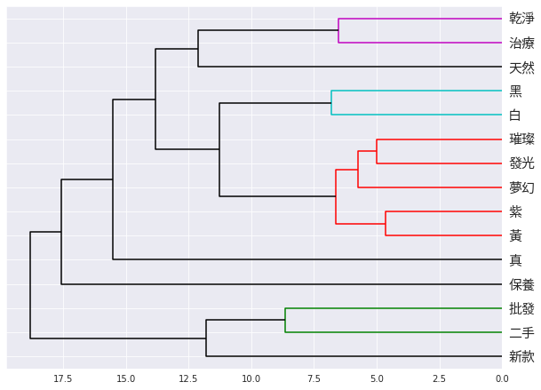

```python
ax
```

# Exercise 2

利用你的word2vec model，請訓練一個簡易的文本分類器。

- document embedding請直接平均文本中所有詞彙的詞向量(e.g.「秋天 快 到 了」直接平均4個詞的詞向量)
- 平均詞向量時，不在word2vec vocabulary裡的詞彙會引發OOV(out of vocabulary)的問題
- 有需要的話可以利用`chinese_stopwords.txt`去除停用詞
- 文本的類別在`ig5000.csv`的'label'欄位中(0=日常;1=廣告)
- 訓練方面，你可以隨意跑一些你喜歡的machine learning models (logistic regression, SVM, random forest,... deep learning除外)
- cross validation和hyperparameters tuning有空再做就好

```python
corpus
```

|  | 0 | 1 | 2 | 3 | 4 | 5 | 6 | 7 | 8 | 9 | 10 | 11 | 12 | 13 | 14 | 15 | 16 | 17 | 18 | 19 | 20 | 21 | 22 | 23 | 24 | 25 | 26 | 27 | 28 | … |
| --- | --- | --- | --- | --- | --- | --- | --- | --- | --- | --- | --- | --- | --- | --- | --- | --- | --- | --- | --- | --- | --- | --- | --- | --- | --- | --- | --- | --- | --- | --- |
| 0 | 0.192990 | -0.353105 | -0.637730 | 0.286617 | -0.227017 | 0.077776 | -0.032824 | 0.015190 | 0.047843 | -0.431044 | -0.390724 | -0.520349 | 0.102561 | 0.403420 | -0.184293 | -0.467724 | -0.071131 | -0.017697 | 0.279205 | 0.122739 | 0.079576 | 0.136973 | 0.144643 | 0.154536 | 0.192177 | 0.168489 | 0.259246 | 0.513220 | 0.524032 | … |
| 1 | 0.264886 | 0.318199 | -0.474538 | 0.335873 | -0.143216 | -0.397015 | 0.117768 | -0.073116 | 0.348682 | 0.123228 | -0.303682 | 0.048323 | -0.008648 | -0.166442 | 0.230317 | -0.143658 | 0.074512 | -0.040029 | -0.170591 | -0.269050 | 0.204180 | -0.284275 | -0.254155 | -0.192583 | 0.216075 | 0.321667 | -0.017492 | 0.160492 | 0.452400 | … |
| 2 | 0.050494 | 0.062182 | -0.277187 | -0.037470 | 0.011746 | -0.018096 | -0.113610 | -0.346261 | -0.225315 | -0.123444 | -0.238500 | 0.051254 | -0.281854 | 0.298280 | 0.214091 | 0.235831 | 0.280631 | 0.613712 | 0.274339 | -0.200207 | -0.086044 | 0.058969 | 0.288521 | 0.031395 | 0.191887 | -0.272521 | -0.179862 | 0.494307 | 0.176095 | … |
| 3 | -0.125321 | -0.162557 | -0.607689 | 0.413347 | 0.085071 | 0.184236 | -0.597848 | 0.074942 | -0.158228 | -0.559513 | -0.572874 | 0.033011 | -0.019276 | 0.132118 | -0.367655 | 0.035912 | 0.281070 | 0.058180 | 0.033551 | 0.415208 | 0.269905 | -0.277114 | 0.486044 | -0.045913 | 0.195630 | 0.421089 | -0.223460 | 0.212908 | -0.376909 | … |
| 4 | 0.063185 | 0.210982 | -0.243325 | 0.171137 | -0.183788 | 0.050384 | -0.005891 | -0.078528 | -0.108301 | -0.260658 | -0.282339 | -0.120371 | -0.160868 | -0.381158 | 0.009456 | -0.320967 | -0.121900 | 0.004943 | 0.424031 | -0.023435 | 0.048744 | 0.345041 | 0.144369 | -0.023117 | 0.165915 | 0.020629 | 0.250530 | 0.150640 | 0.184260 | … |
| ... | ... | ... | ... | ... | ... | ... | ... | ... | ... | ... | ... | ... | ... | ... | ... | ... | ... | ... | ... | ... | ... | ... | ... | ... | ... | ... | ... | ... | ... | … |
| 4696 | 0.282435 | 0.074297 | -0.421048 | 0.347515 | -0.136521 | -0.091181 | 0.132755 | -0.547622 | -0.030642 | -0.131317 | -0.416144 | -0.004755 | -0.068136 | -0.172712 | -0.023549 | -0.192095 | -0.176450 | -0.176789 | -0.329978 | 0.023790 | -0.057347 | 0.184864 | -0.029132 | 0.133687 | 0.005930 | 0.202590 | -0.388707 | 0.272818 | -0.123870 | … |
| 4697 | -0.151734 | 0.227527 | 0.133010 | -0.182801 | 0.391955 | 0.225135 | -0.056522 | -0.116220 | -0.401912 | 0.094744 | -0.350631 | -0.103873 | 0.089112 | 0.249706 | 0.005001 | 0.211881 | 0.150141 | 0.092068 | 0.439950 | 0.370598 | -0.569843 | -0.115176 | 0.494831 | -0.057061 | -0.058791 | -0.342543 | 0.217546 | 0.019957 | 0.447610 | … |
| 4698 | 0.223363 | 0.277550 | 0.123264 | 0.190416 | 0.275921 | 0.008109 | 0.156124 | -0.110076 | -0.184827 | -0.019191 | 0.401586 | -0.198265 | -0.108461 | -0.219342 | 0.224414 | -0.322053 | -0.246958 | -0.104937 | 0.131942 | -0.240572 | 0.263559 | 0.187364 | -0.168822 | -0.289155 | -0.101418 | 0.094267 | 0.035715 | 0.121431 | 0.239185 | … |
| 4699 | -0.170621 | -0.276254 | -0.066679 | 0.620003 | -0.257801 | -0.228575 | -0.806770 | 0.462319 | 0.166028 | -0.710090 | -0.903813 | 0.114758 | -0.276176 | 0.004084 | -0.762482 | -0.233864 | -0.266798 | -0.275882 | 0.209364 | 0.759455 | -0.146448 | 0.001278 | 0.571981 | -0.086682 | 0.290481 | 0.204539 | -0.555903 | -0.135969 | -0.865382 | … |
| 4700 | -0.172238 | 0.005218 | -0.223989 | -0.056606 | 0.018231 | -0.059234 | 0.184363 | 0.283776 | -0.359577 | -0.237804 | -0.075929 | 0.108184 | 0.360093 | -0.118059 | 0.009622 | -0.277410 | 0.143975 | -0.098239 | 0.125741 | -0.008099 | 0.286480 | -0.196871 | 0.170116 | -0.308290 | -0.118749 | 0.148470 | -0.049988 | -0.230420 | 0.008479 | … |

4701 rows × 201 columns

```python
print("Naive Bayes:", gnb.score(X_test, y_test))
print("Logistic Regression:",lgr.score(X_test, y_test))
print("Random Forest:", rfc.score(X_test, y_test))
```

```
Naive Bayes: 0.5207226354941552
Logistic Regression: 0.4962805526036132
Random Forest: 0.5217853347502657
```

## 表現最好的model

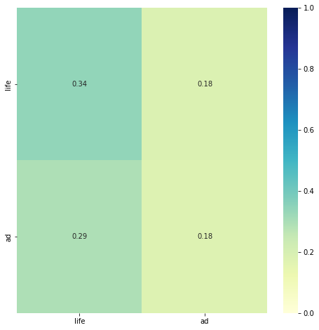

```python
plt.figure(figsize=(8, 8))
sns.heatmap(conf, xticklabels=labels, yticklabels=labels,annot=True, vmin=0, vmax=1, cmap="YlGnBu")
```